# EXPLORATORY ANALYSIS OF CLASSIFICATION MODELS WITH SKLEARN AND BANK MARKETING DATA.

### Abstract:

The data is related with direct marketing campaigns (phone calls) of a Portuguese banking institution. The classification goal is to predict if the client will subscribe a term deposit (variable y).

#### Source:

Dataset from : http://archive.ics.uci.edu/ml/datasets/Bank+Marketing#

## Loading and getting ideas about the data

```python
import numpy as np # linear algebra
import pandas as pd # data processing


import os
for dirname, _, filenames in os.walk('/kaggle/input'):
    for filename in filenames:
        print(os.path.join(dirname, filename))
```

```
/kaggle/input/bank-marketing/bank-additional-names.txt
/kaggle/input/bank-marketing/bank-additional-full.csv
```

```python
df = pd.read_csv('../input/bank-marketing/bank-additional-full.csv', sep=";") #Full dataframe
```

```python
df.head()
```

|  | age | job | marital | education | default | housing | loan | contact | month | day_of_week | ... | campaign | pdays | previous | poutcome | emp.var.rate | cons.price.idx | cons.conf.idx | euribor3m | nr.employed | y |
| --- | --- | --- | --- | --- | --- | --- | --- | --- | --- | --- | --- | --- | --- | --- | --- | --- | --- | --- | --- | --- | --- |
| 0 | 56 | housemaid | married | basic.4y | no | no | no | telephone | may | mon | ... | 1 | 999 | 0 | nonexistent | 1.1 | 93.994 | -36.4 | 4.857 | 5191.0 | no |
| 1 | 57 | services | married | high.school | unknown | no | no | telephone | may | mon | ... | 1 | 999 | 0 | nonexistent | 1.1 | 93.994 | -36.4 | 4.857 | 5191.0 | no |
| 2 | 37 | services | married | high.school | no | yes | no | telephone | may | mon | ... | 1 | 999 | 0 | nonexistent | 1.1 | 93.994 | -36.4 | 4.857 | 5191.0 | no |
| 3 | 40 | admin. | married | basic.6y | no | no | no | telephone | may | mon | ... | 1 | 999 | 0 | nonexistent | 1.1 | 93.994 | -36.4 | 4.857 | 5191.0 | no |
| 4 | 56 | services | married | high.school | no | no | yes | telephone | may | mon | ... | 1 | 999 | 0 | nonexistent | 1.1 | 93.994 | -36.4 | 4.857 | 5191.0 | no |

5 rows × 21 columns

```python
df.info()
```

```
<class 'pandas.core.frame.DataFrame'>
RangeIndex: 41188 entries, 0 to 41187
Data columns (total 21 columns):
 #   Column          Non-Null Count  Dtype
---  ------          --------------  -----
 0   age             41188 non-null  int64
 1   job             41188 non-null  object
 2   marital         41188 non-null  object
 3   education       41188 non-null  object
 4   default         41188 non-null  object
 5   housing         41188 non-null  object
 6   loan            41188 non-null  object
 7   contact         41188 non-null  object
 8   month           41188 non-null  object
 9   day_of_week     41188 non-null  object
 10  duration        41188 non-null  int64
 11  campaign        41188 non-null  int64
 12  pdays           41188 non-null  int64
 13  previous        41188 non-null  int64
 14  poutcome        41188 non-null  object
 15  emp.var.rate    41188 non-null  float64
 16  cons.price.idx  41188 non-null  float64
 17  cons.conf.idx   41188 non-null  float64
 18  euribor3m       41188 non-null  float64
 19  nr.employed     41188 non-null  float64
 20  y               41188 non-null  object
dtypes: float64(5), int64(5), object(11)
memory usage: 6.6+ MB
```

### Many categorical columns. Lets see the unique values of these columns and decide to do one hot encoder or something different.

```python
for col in df.iloc[:,1:10]:  #Printing categorical columns
    print(f'{col}: {df[col].unique()}')
    print('\n')
```

```
job: ['housemaid' 'services' 'admin.' 'blue-collar' 'technician' 'retired'
 'management' 'unemployed' 'self-employed' 'unknown' 'entrepreneur'
 'student']


marital: ['married' 'single' 'divorced' 'unknown']


education: ['basic.4y' 'high.school' 'basic.6y' 'basic.9y' 'professional.course'
 'unknown' 'university.degree' 'illiterate']


default: ['no' 'unknown' 'yes']


housing: ['no' 'yes' 'unknown']


loan: ['no' 'yes' 'unknown']


contact: ['telephone' 'cellular']


month: ['may' 'jun' 'jul' 'aug' 'oct' 'nov' 'dec' 'mar' 'apr' 'sep']


day_of_week: ['mon' 'tue' 'wed' 'thu' 'fri']
```

```python
categorical_cols = ['job','marital','education','default','housing','loan','contact','month','day_of_week','poutcome']
non_cat = pd.get_dummies(df, columns=categorical_cols)
```

```python
non_cat.info()
```

```
<class 'pandas.core.frame.DataFrame'>
RangeIndex: 41188 entries, 0 to 41187
Data columns (total 64 columns):
 #   Column                         Non-Null Count  Dtype
---  ------                         --------------  -----
 0   age                            41188 non-null  int64
 1   duration                       41188 non-null  int64
 2   campaign                       41188 non-null  int64
 3   pdays                          41188 non-null  int64
 4   previous                       41188 non-null  int64
 5   emp.var.rate                   41188 non-null  float64
 6   cons.price.idx                 41188 non-null  float64
 7   cons.conf.idx                  41188 non-null  float64
 8   euribor3m                      41188 non-null  float64
 9   nr.employed                    41188 non-null  float64
```

[output cut: 56 more lines]

```python
non_cat.isnull().sum().sum()
```

```
0
```

### No categorical values, no NULL values. Changing target variable to numerical.

```python
non_cat.y = non_cat.y.map(dict(yes=1, no=0))
```

### Correlation analysis

```python
corr = non_cat.corr()
print(corr.y.sort_values(ascending=False)[:10])
```

```
y                   1.000000
duration            0.405274
poutcome_success    0.316269
previous            0.230181
contact_cellular    0.144773
month_mar           0.144014
month_oct           0.137366
month_sep           0.126067
default_no          0.099344
job_student         0.093955
Name: y, dtype: float64
```

### Top 10 higly correlated columns with the target variable.

Duration: last contact duration, in seconds (numeric). Important note: this attribute highly affects the output target

Poutcome: outcome of the previous marketing campaign

Previous: number of contacts performed before this campaign and for this client (numeric)

Contact: contact communication type. Cellular seems to be more effective.

```python
import matplotlib.pyplot as plt
import seaborn as sns
plt.style.use('dark_background')

x = corr.y.sort_values(ascending=False)[:10]
```

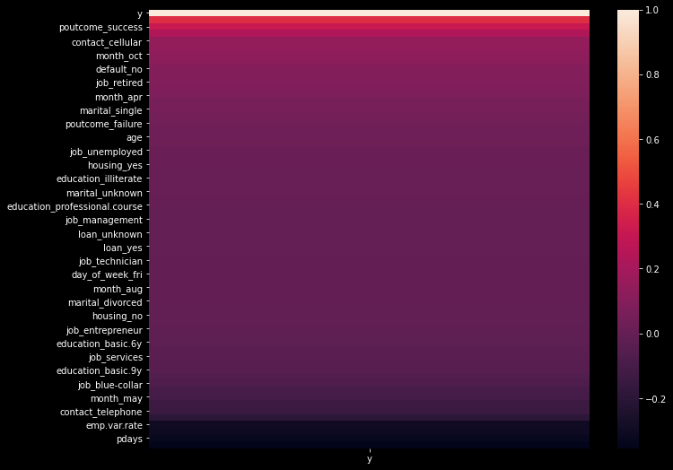

```python
#plotting heatmap of the results from correation analysis
f, ax = plt.subplots(figsize=(11, 9))
cmap = sns.diverging_palette(230, 20, as_cmap=True)
sns.heatmap(corr[['y']].sort_values(['y'],ascending=False))
```

### Splitting target and predictor variables

```python
y = non_cat['y'].copy()
X = non_cat.drop('y',axis=1).copy()
```

### Standardizing the predictor variables

```python
from sklearn.preprocessing import StandardScaler
cols = X.columns
scaler = StandardScaler()
standard = scaler.fit_transform(X)
standard_df = pd.DataFrame(standard, columns =cols)
```

### Sample Distribution

The samples are highly varied. AUC can be the final metric, along with other feature engineering techniques.

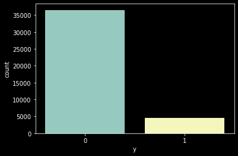

```python
import seaborn as sns
ax = sns.countplot(y)
```

### AUC_ROC function

> The ROC(Reciever operator characterstics) curve is a performance measurement for a classification problem at various threshold. A standard accuracy labels an examples as postive if the prediction is >50% confident and negative if it is <50% confident, whereas, ROC-AUC method will consider all the thresholds. It is calculated by plotting the true positive and false positive rates. This method is particulary useful when the data is imbalanced or we need to avoid certain bias in the training process. $$ {TPR} = {TP \over {TP+FN}} $$ $$ {FPR} = {FP \over {TN+FP}} $$ $$ \text{where TP and TN is true positive and true negative whereas FP and FN are fale positive and false negative.} $$

> The AUC(Area under the curve) measure the area of under the TPR-FPR plot and it ranges from o to 1. 0 is the worst measure of speratability, wheras 0.5 is no class seperation capacity, and 1 means best class seperation capacity.

```python
from sklearn.metrics import roc_curve, roc_auc_score
import matplotlib.pyplot as plt
'''
AUC ploting function that will be used later on
'''

def roc_auc(y_test,y_preds,roc_auc):
    fpr, tpr, threshold = roc_curve(y_test, y_preds)

    plt.title('Receiver Operating Characteristic')
    plt.plot(fpr, tpr, 'b', label = 'AUC = %0.2f' % roc_auc)
    plt.legend(loc = 'lower right')
    plt.plot([0, 1], [0, 1],'r--')
    plt.xlim([0, 1])
    plt.ylim([0, 1])
    plt.ylabel('True Positive Rate')
    plt.xlabel('False Positive Rate')
    plt.show()
```

### Train_test split

```python
from sklearn.model_selection import train_test_split
X_train, X_test, y_train, y_test = train_test_split(standard_df,y,test_size=0.2,random_state = 42)
```

# Training models

Okay, we will begin with training inital models to understand the baseline perfromance before we can do some feature engineering to make the models better.

### KNN

> For the first model we will begin with KNN. One of the most common and simples supervised classification technique, usually KNNs are very good for linearly sperable data but it also works with non-linear data aswell. KNN works by by calculating the eucledian distance between k data points and assigns them to a group based on the resultant distance.

> Advantages: Robust to noise

> Disadvantage: Slow, Finding k value is crucial

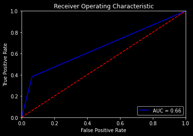

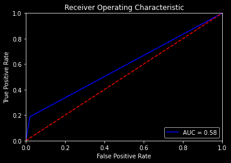

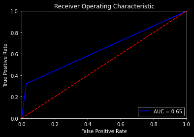

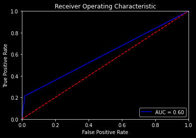

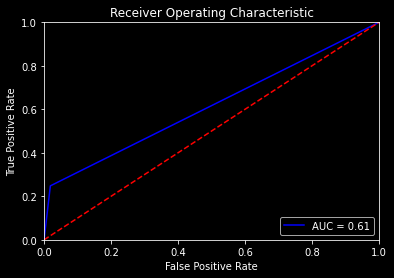

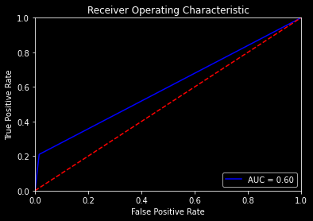

```
k: 5, accuracy: 0.8983976693372178,cross validated score: 0.8379283520227105, auc: 0.6591968284955051
```

```
((5, 0.8983976693372178), (20, 0.8379283520227105), (1, 0.6591968284955051))
```

```python
from sklearn.neighbors import KNeighborsClassifier
from sklearn.model_selection import cross_val_score
from sklearn.metrics import accuracy_score
import operator

k_value = [1,2,5,10,15,20]



def KNN(k_value,xtrain,ytrain,xtest,ytest):
    acc = []
    cv = []
    auc_score = []
    for i in k_value:                                    #iterate the k values
        classifier = KNeighborsClassifier(n_neighbors=i) #train multiple models and save their accuracy, CV and auc score
        classifier.fit(X_train,y_train)
        y_pred = classifier.predict(X_test)
        accuracy = accuracy_score(y_test,y_pred)
        cv_score = cross_val_score(classifier,X,y,cv=10)
        cv_mean = cv_score.mean()
        auc = roc_auc_score(y_test,y_pred)
        roc_auc(y_test,y_pred,auc)

        acc.append((i,accuracy))
        cv.append((i,cv_mean))
        auc_score.append((i, auc))
    best_acc = max(acc,key=operator.itemgetter(1))
    best_cv = max(cv,key=operator.itemgetter(1))
    best_auc = max(auc_score,key=operator.itemgetter(1))
    print(f'k: {best_acc[0]}, accuracy: {best_acc[1]},cross validated score: {best_cv[1]}, auc: {best_auc[1]}')

    return best_acc, best_cv, best_auc





KNN(k_value,X_train,y_train,X_test,y_test)
```

### Decision Tree classifier.

Decision trees are another supervised learning technique. It is a tree-structured classifier, where internal nodes represent the features of a dataset, branches represent the decision rules and each leaf node represents the outcome.

> Disadvantage: prone to overfitting as the model is too complex, but can be rectified with Randomforest implementation.

> Advantage: There is less requirement of data cleaning compared to other algorithms.

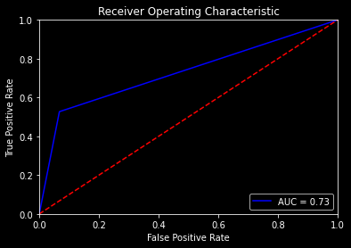

```
Decision Tree accuracy: 0.8865015780529255,cross validated score: 0.6499352436457827, auc: 0.7298831115481808
```

```python
from sklearn.tree import DecisionTreeClassifier
from sklearn import tree
from sklearn.metrics import roc_auc_score


def DTC(xtrain,ytrain,xtest,ytest):
    classifier = DecisionTreeClassifier()
    classifier.fit(X_train,y_train)
    y_pred = classifier.predict(X_test)
    accuracy = accuracy_score(y_test,y_pred)
    cv_score = cross_val_score(classifier,X,y,cv=10)
    auc = roc_auc_score(y_test,y_pred)
    roc_auc(y_test,y_pred,auc)
    print(f'Decision Tree accuracy: {accuracy},cross validated score: {cv_score.mean()}, auc: {auc}')


DTC(X_train,y_train,X_test,y_test)
```

### SVM

> SVM is one of the most renonwed machine learning model. It has held state of arts on several types of classification problems.

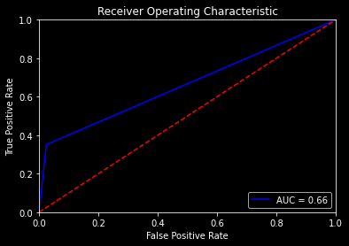

```
SVM accuracy: 0.9044671036659383,cross validated score: 0.8944343493548713, auc: 0.6635436612746501
```

```python
from sklearn import svm

def SVM(xtrain,ytrain,xtest,ytest):
    classifier = svm.SVC(kernel='poly')
    classifier.fit(X_train,y_train)
    y_pred = classifier.predict(X_test)
    accuracy = accuracy_score(y_test,y_pred)
    cv_score = cross_val_score(classifier,X,y,cv=10)
    auc = roc_auc_score(y_test,y_pred)
    roc_auc(y_test,y_pred,auc)
    print(f'SVM accuracy: {accuracy},cross validated score: {cv_score.mean()}, auc: {auc}')

SVM(X_train,y_train,X_test,y_test)
```

### XGB classifier

> [xgboost](https://xgboost.readthedocs.io/en/latest/)is an optimized distributed gradient boosting library designed to be highly efficient, flexible and portable. It implements machine learning algorithms under the Gradient Boosting framework.

[output not shown]

[output not shown]

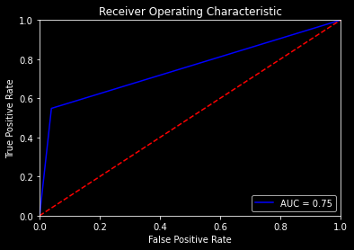

```
XGB accuracy: 0.9139354212187424,cross validated score: 0.672345434588595, auc: 0.7546820916757526
```

```python
from xgboost import XGBClassifier

def XGB(X_train,y_train,X_test,y_test):
    classifier = XGBClassifier()
    classifier.fit(X_train,y_train)
    y_pred = classifier.predict(X_test)
    accuracy = accuracy_score(y_test,y_pred)
    cv_score = cross_val_score(classifier,X,y,cv=10)
    auc = roc_auc_score(y_test,y_pred)
    roc_auc(y_test,y_pred,auc)
    print(f'XGB accuracy: {accuracy},cross validated score: {cv_score.mean()}, auc: {auc}')

XGB(X_train,y_train,X_test,y_test)
```

## Feature Engineering: Up-Sampling with SMOTE

#### Train Set

```python
from imblearn.over_sampling import SMOTE


sm = SMOTE(random_state = 2)
X_train_res, y_train_res = sm.fit_resample(X_train, y_train.ravel())

print(f'Before SMOTE count of label 1: {sum(y_train==1)}')
print(f'Before SMOTE count of label 0: {sum(y_train==0)}')

print('\n')

print(f'After SMOTE count of label 1: {sum(y_train_res==1)}')
print(f'After SMOTE count of label 0: {sum(y_train_res==0)}')
```

```
Before SMOTE count of label 1: 3705
Before SMOTE count of label 0: 29245


After SMOTE count of label 1: 29245
After SMOTE count of label 0: 29245
```

#### Test set

```python
X_test_res, y_test_res = sm.fit_resample(X_test, y_test.ravel())

print(f'Before SMOTE count of label 1: {sum(y_test==1)}')
print(f'Before SMOTE count of label 0: {sum(y_test==0)}')

print('\n')

print(f'After SMOTE count of label 1: {sum(y_test_res==1)}')
print(f'After SMOTE count of label 0: {sum(y_test_res==0)}')
```

```
Before SMOTE count of label 1: 935
Before SMOTE count of label 0: 7303


After SMOTE count of label 1: 7303
After SMOTE count of label 0: 7303
```

## Feature Engineering: Down-Sampling with NearMiss

#### Train Set

```python
from imblearn.under_sampling import NearMiss

nr = NearMiss()

X_train_miss, y_train_miss = nr.fit_resample(X_train, y_train.ravel())

print(f'Before NearMiss count of label 1: {sum(y_train==1)}')
print(f'Before NearMiss count of label 0: {sum(y_train==0)}')

print('\n')

print(f'After NearMiss count of label 1: {sum(y_train_miss==1)}')
print(f'After NearMiss count of label 0: {sum(y_train_miss==0)}')
```

```
Before NearMiss count of label 1: 3705
Before NearMiss count of label 0: 29245


After NearMiss count of label 1: 3705
After NearMiss count of label 0: 3705
```

#### Test Set

```python
X_test_miss, y_test_miss = nr.fit_resample(X_test, y_test.ravel())

print(f'Before NearMiss count of label 1: {sum(y_test==1)}')
print(f'Before NearMiss count of label 0: {sum(y_test==0)}')

print('\n')

print(f'After NearMiss count of label 1: {sum(y_test_miss==1)}')
print(f'After NearMiss count of label 0: {sum(y_test_miss==0)}')
```

```
Before NearMiss count of label 1: 935
Before NearMiss count of label 0: 7303


After NearMiss count of label 1: 935
After NearMiss count of label 0: 935
```

# BankMarket Class

> Now that we have trained few models, did some feature engineering, and understood how the results look, we can now create a single object that can be used to train, test and predict with simple user inputs. This is a rather simple implementation with OOP and can be easily extened with GUI elements later on if needed, but since this is a kaggle challenge it is not implemented.

The object asks for user input of the type of model to be trained. After selecting it will train and test automatically and save the model with the same name as the input string given by the user, which can be later on be used to predict samples by simply inputting the filepath of the model. The object takes X_train, X_test, y_train, y_test for training and testing and any array or dataframe of shape (1,63) for predicting a class.

```python
from sklearn.metrics import roc_curve, roc_auc_score
import matplotlib.pyplot as plt
from sklearn.tree import DecisionTreeClassifier
from sklearn.neighbors import KNeighborsClassifier
from sklearn.model_selection import cross_val_score
from sklearn import tree
from sklearn.metrics import roc_auc_score,accuracy_score
from sklearn import svm
from xgboost import XGBClassifier
import pickle
import os
import warnings
warnings.filterwarnings("ignore")

'''
Takes input as X_train,y_train,X_test and y_test.
train_KNN: k-Nearest Neighbor classifier
train_SVM: Support Vector Machine classifier
train_DTC: Decision Tree classifier
train_XGB: Gradient Boost classifier
roc_auc : plots the AUC function for a trained model

test: Returns accuracy, cross validated accuracy and auc score

train: Trains the different models based on the user input preference

predict: predict new values.Takes input as array of shape (1,63), outputs classified label
'''



class BankMarket():
    def __init__(self,xtr,ytr,xte,yte):
        self.xtr = xtr
        self.ytr = ytr
        self.xte = xte
        self.tye = yte


    def train_KNN(self,X_train,y_train):

        classifier = KNeighborsClassifier(n_neighbors=20)
        classifier.fit(X_train,y_train)
        print('Finished Training, Begin Testing')

        return classifier

    def train_DTC(self,X_train,y_train):

        classifier = DecisionTreeClassifier()
        classifier.fit(X_train,y_train)
        print('Finished Training, Begin Testing')

        return classifier

    def train_SVM(self,X_train,y_train):

        classifier = DecisionTreeClassifier()
        classifier.fit(X_train,y_train)
        print('Finished Training, Begin Testing')

        return classifier

    def train_XGB(self,X_train,y_train):

        classifier = XGBClassifier(eval_metric='logloss')
        classifier.fit(X_train,y_train)
        print('Finished Training, Begin Testing')

        return classifier

    def roc_auc(self,y_test,y_preds,roc_auc,algorithm):
        fpr, tpr, threshold = roc_curve(y_test, y_preds)

        plt.title(f'Receiver Operating Characteristic: {algorithm}')
        plt.plot(fpr, tpr, 'b', label = 'AUC = %0.2f' % roc_auc)
        plt.legend(loc = 'lower right')
        plt.plot([0, 1], [0, 1],'r--')
        plt.xlim([0, 1])
        plt.ylim([0, 1])
        plt.ylabel('True Positive Rate')
        plt.xlabel('False Positive Rate')
        plt.show()

    def save(self,filename,model):
        pickle.dump(model,open(filename,'wb'))

    def test(self,classifier,X_test,y_test,algorithm):
        print('\n')

        y_pred = classifier.predict(X_test)
        accuracy = accuracy_score(y_test,y_pred)
        cv_score = cross_val_score(classifier,X_train,y_train,cv=10)
        auc = roc_auc_score(y_test,y_pred)
        self.roc_auc(y_test,y_pred,auc,algorithm)
        print(f'{algorithm} finished testing with accuracy as {accuracy}, cv_score as {cv_score.mean()}, auc score as {auc}')

        return y_pred, accuracy, cv_score,auc


    def train(self,xtr,ytr,xte,yte):
        print('Select type of algorithm')
        print('options:','KNN','DTC','SVM','XGB')
        clf = input()
        while clf not in ('KNN','DTC','SVM','XGB'):
            print('Please Enter Valid Algorithm')
            clf = input()
        if clf == 'KNN':
            classifier = self.train_KNN(xtr,ytr)

        elif clf == 'DTC':
            classifier = self.train_DTC(xtr,ytr)

        elif clf =='SVM':
            classifier = self.train_SVM(xtr,ytr)
        elif clf == 'XGB':
            classifier = self.train_XGB(xtr,ytr)

        y_pred, accuracy, cv_score,auc = self.test(classifier, xte,yte,clf)
        filename = clf+'.sav'

        self.save(filename,classifier)


    def predict(self,new_input):
        print('Give model save path')
        path = input()

        model = pickle.load(open(path,'rb'))
        pred = model.predict(new_input)
        if np.all(pred==0):
            print('Negative subscription')
        else:
            print('Positive subscription')
```

### Original non engineered data

Same results we saw previously.

```
Select type of algorithm
options: KNN DTC SVM XGB
 XGB
Finished Training, Begin Testing
```

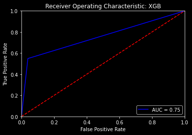

```
XGB finished testing with accuracy as 0.9139354212187424, cv_score as 0.9140819423368741, auc score as 0.7546820916757526
```

```python
bank = BankMarket(X_train, y_train,X_test,y_test)
bank.train(X_train, y_train,X_test,y_test)
```

### Train with upsampled data

```
Select type of algorithm
options: KNN DTC SVM XGB
 XGB
Finished Training, Begin Testing
```

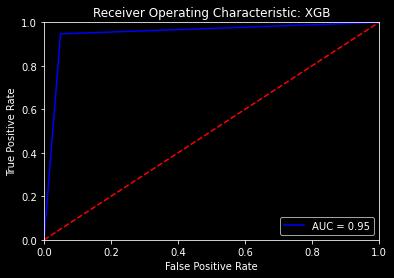

```
XGB finished testing with accuracy as 0.9489935642886485, cv_score as 0.9140819423368741, auc score as 0.9489935642886486
```

```python
bank_up = BankMarket(X_train_res, y_train_res,X_test_res,y_test_res)
bank_up.train(X_train_res, y_train_res,X_test_res,y_test_res)
```

### Train with Down-sampled data

Significantly better as well. Although upsampling should be considered as the final model.

```
Select type of algorithm
options: KNN DTC SVM XGB
 XGB
Finished Training, Begin Testing
```

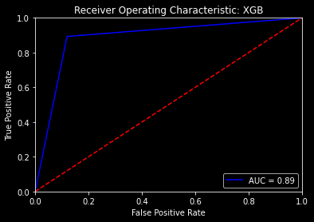

```
XGB finished testing with accuracy as 0.8866310160427807, cv_score as 0.9140819423368741, auc score as 0.8866310160427808
```

```python
bank = BankMarket(X_train_miss, y_train_miss,X_test_miss,y_test_miss)
bank.train(X_train_miss, y_train_miss,X_test_miss,y_test_miss)
```

## Predicting new inputs to get a label class

#### Can input any new values, will output label.

```python
#giving a random example for the lack of new data. But any (1,63) shape array works
random_ip = np.random.uniform(-2,2,(1,63))
bank.predict(random_ip)
```

```
Give model save path
 ./XGB.sav
Positive subscription
```

### Great. Apparently the randomly generated 63 values were predicted as positive subscription. Now we have a classifier with AUC of 89 for predicting whether a subject will be a subscriber or not.